# 2019 Ford GoBike System Dataset Exploration and Visualization

###### by (Bukola Ajayi)

## Investigation Overview

In this investigation, I wanted to highlight the importance and value of data visualization techniques in the data analysis process. This involves the comparison of one, two or more variables and also predicting their insight and impact on each other.

## Dataset Overview

This dataset includes information about individual rides made on a bike-sharing system covering the greater San Francisco Bay area in the year 2019.

## 1. The Users' Distribution

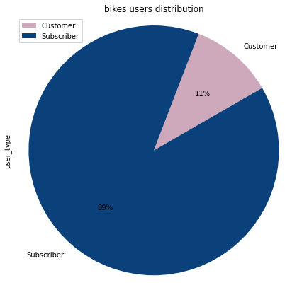

> There are more of subscribers than customers, this shows a lot of people actually subcribed to the bikes sharing plan.

## 2. Most Popular Stations

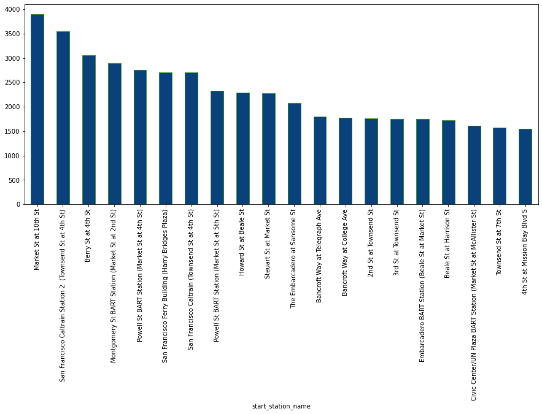

#### The top twenty most popular start station includes:

- Market St at 10th St
- San Francisco Caltrain Station 2 (Townsend St at 4th St)
- Berry St at 4th St
- Montgomery St BART Station (Market St at 2nd St)
- Powell St BART Station (Market St at 4th St)
- San Francisco Ferry Building (Harry Bridges Plaza)
- San Francisco Caltrain (Townsend St at 4th St)
- Powell St BART Station (Market St at 5th St)
- Howard St at Beale St
- Steuart St at Market St
- The Embarcadero at Sansome St
- Bancroft Way at Telegraph Ave
- Bancroft Way at College Ave
- 2nd St at Townsend St
- 3rd St at Townsend St
- Embarcadero BART Station (Beale St at Market St)
- Beale St at Harrison St
- Civic Center/UN Plaza BART Station (Market St at McAllister St)
- Townsend St at 7th St
- 4th St at Mission Bay Blvd S

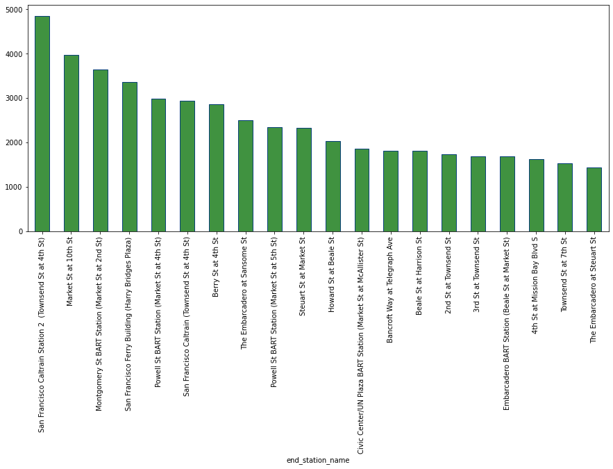

#### The top twenty most popular end station includes:

- San Francisco Caltrain Station 2 (Townsend St at 4th St)
- Market St at 10th St
- Montgomery St BART Station (Market St at 2nd St)
- San Francisco Ferry Building (Harry Bridges Plaza)
- Powell St BART Station (Market St at 4th St)
- San Francisco Caltrain (Townsend St at 4th St)
- Berry St at 4th St
- The Embarcadero at Sansome St
- Powell St BART Station (Market St at 5th St)
- Steuart St at Market St
- Howard St at Beale St
- Civic Center/UN Plaza BART Station (Market St at McAllister St)
- Bancroft Way at Telegraph Ave
- Beale St at Harrison St
- 2nd St at Townsend St
- 3rd St at Townsend St
- Embarcadero BART Station (Beale St at Market St)
- 4th St at Mission Bay Blvd S
- Townsend St at 7th St
- The Embarcadero at Steuart St

## 3. Trip Duration based on Gender

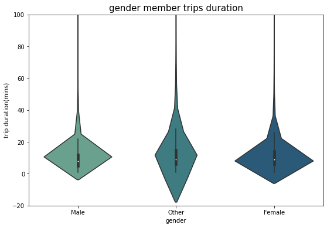

It can be seen that the females and other genders have a higher average trip duration when compared to the males.

## 4. Trip Distribution Based on Gender

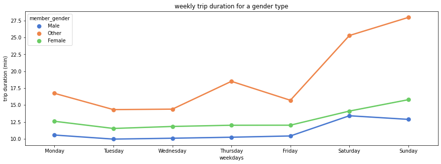

## 5. Users' Distribution on Trips

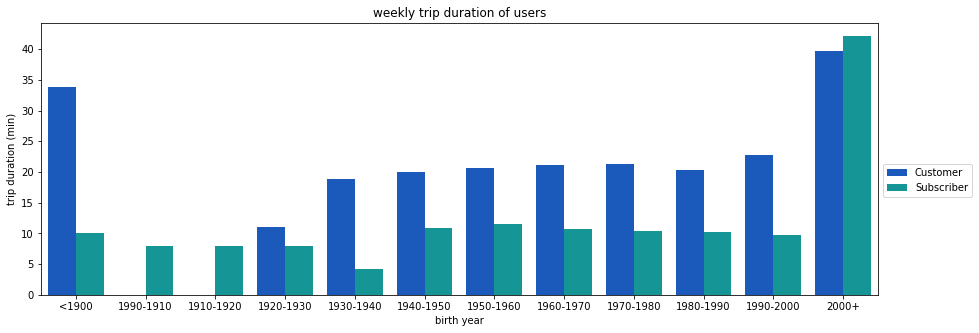